# Manejo de datos con R (I): the tidyverse way

Módulo práctico de ITA  
(Grupo M)

### Data munging: the tidyverse way

Aprendimos a cargar datos, pero es raro que los datos estén preparados para empezar nuestro análisis, así que hay que “arreglar/limpiar” los datos. Para ello, tenemos que:

1. Hacer nuestros datos TIDY
2. Arreglarlos/modificarlos para que sean útiles para nuestros propósitos

Arreglando los datos

- El procesado/limpieza de los datos suele ocupar un 80% del tiempo de un análisis de datos; así que el workflow sería más bien así:

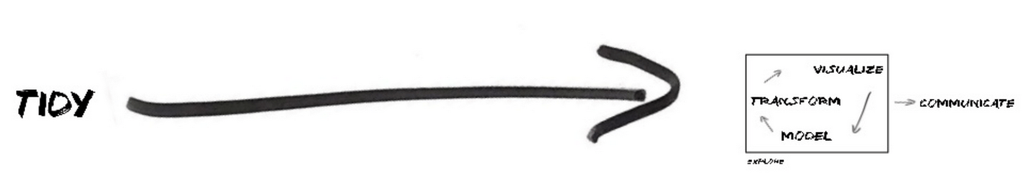

- Aprenderemos a limpiar y transformar datos en R. Priorizaremos la nueva forma de hacer las cosas en R (o workflow) conocido como [**tidyverse**](https://www.tidyverse.org/): un **conjunto de paquetes** que trabajan en armonía y que permiten una nueva forma de escribir/programar en R.

principales pkgs del Tidyverse

- **`tidyr`**: convertir a tidy data
- **`dplyr`**: para manipular datos
- **`ggplot2`**: para hacer gráficos
- … y algunos más

[figure not shown]

aquí nos centraremos principalmente en dos paquetes: **`dplyr`** y **`tidyr`**

“Filosofía” del Tidyverse

> Programs must be written for people to read, and only incidentally for machines to execute – Hal Abelson

dos principios del *tidyverse*

- Los scripts deben ser **“fácilmente” legibles por las personas**
- **Resolver problemas complejos** encadenando funciones simples con el **operador pipe (`%>%`)**